# Univariate descriptive analysis preprocessed

2023-09-26

# Univariate Descriptive analysis

Les dimensions del nostre dataset són:

```
N =  8539
```

```
K =  46
```

Per tal de poder observar les variables, procedirem a fer els bar plots, pie charts (categòriques) i els histogrames i boxplots (per les numèriques).

## track_id

[1] 5aAx2yezTd8zXrkmtKl66Z 7BKLCZ1jbUBVqRi2FVlTVw 5knuzwU65gJK7IF5yJsuaW [4] 4pdPtRcBmOSQDlJ3Fk945m 3NdDpSvN911VPGivFlV5d0 5MFzQMkrl1FOOng9tq6R9r 1210 Levels: 00lNx0OcTJrS3MKHcB80HY … 7zgqtptZvhf8GEmdsM2vp2

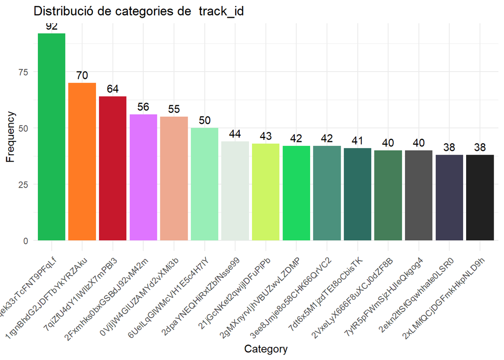

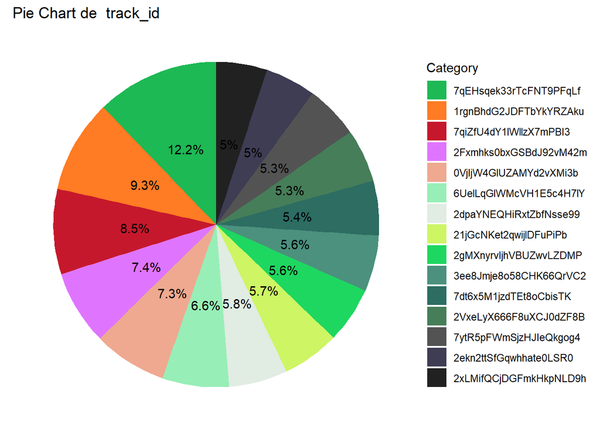

Nombre de modalitats: 1210

Moda: 7qEHsqek33rTcFNT9PFqLf

Freqüència màxima: 92

## track_name

[1] Starboy  
[2] Closer  
[3] Rockabye (feat. Sean Paul & Anne-Marie)  
[4] Let Me Love You  
[5] I Don’t Wanna Live Forever (Fifty Shades Darker) - From “Fifty Shades Darker (Original Motion Picture Soundtrack)” [6] Don’t Wanna Know  
1019 Levels: …Ready For It? @ MEH ’tis the damn season … ZEZE (feat. Travis Scott & Offset)

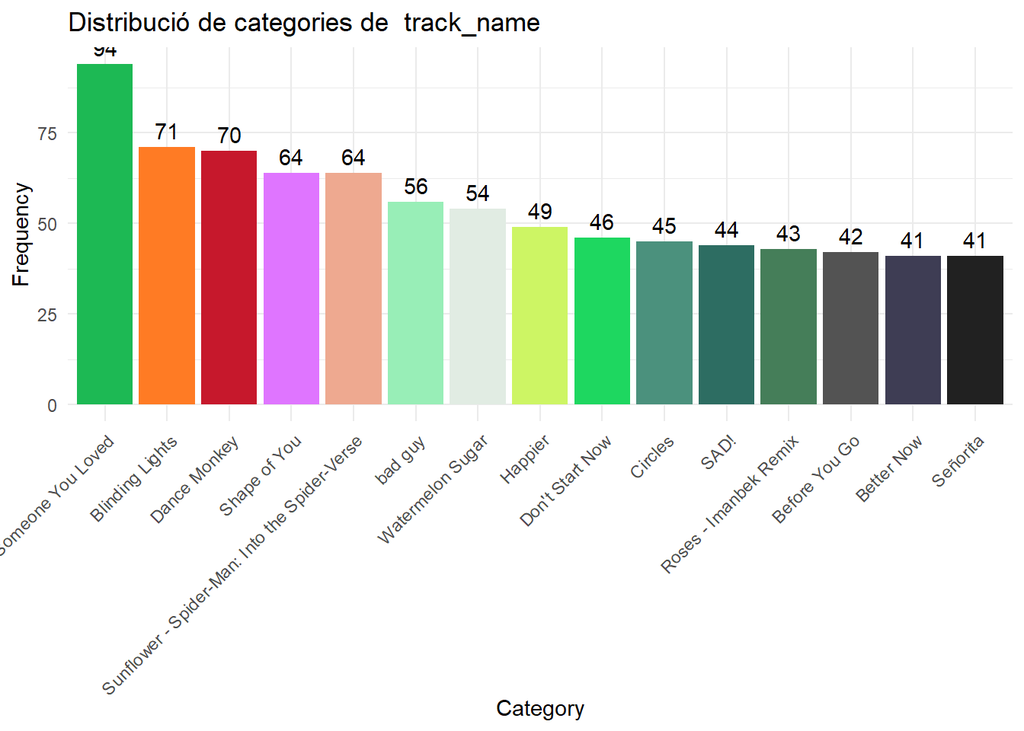

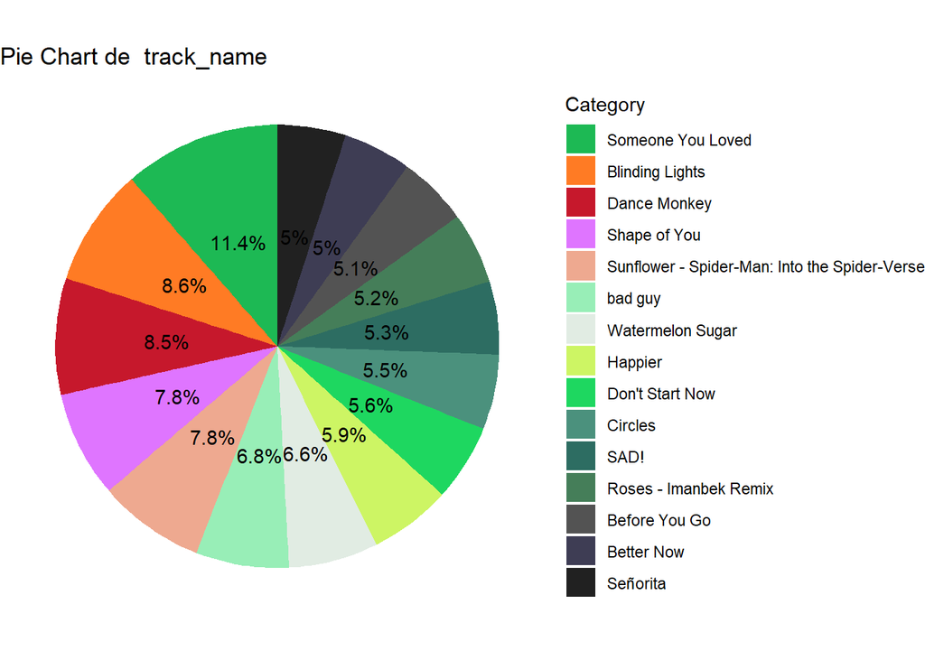

Nombre de modalitats: 1019

Moda: Someone You Loved

Freqüència màxima: 94

## track_popularity

[1] 0 84 75 2 0 0

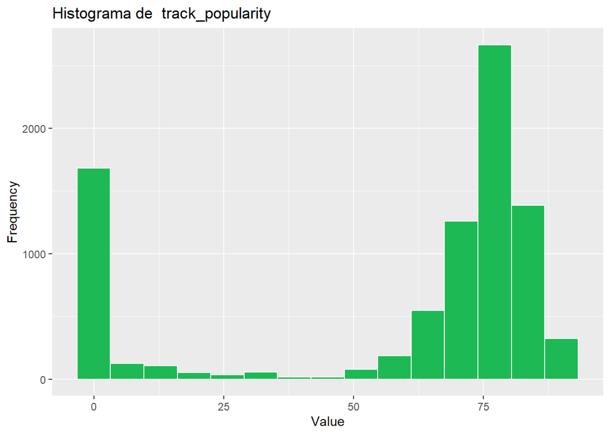

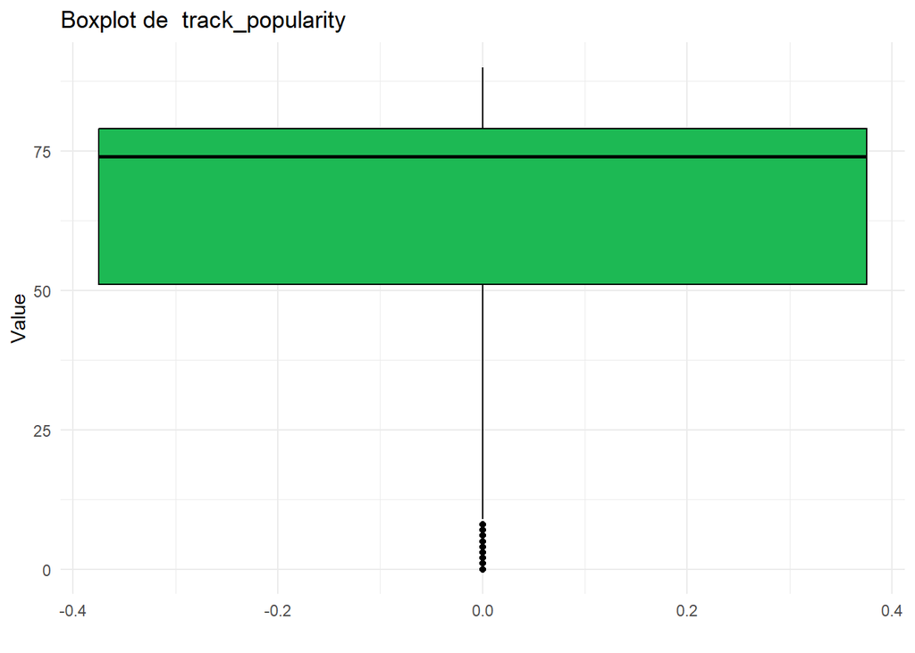

Mínim: 0 Màxim: 90

Primer quartil: 51 Mediana: 74 Tercer quartil: 79 Mitjana: 58.06289

## album_name

[1] Starboy  
[2] Closer  
[3] Rockabye (feat. Sean Paul & Anne-Marie)  
[4] Encore  
[5] I Don’t Wanna Live Forever (Fifty Shades Darker) [6] Don’t Wanna Know  
769 Levels: “Awaken, My Love!” …Ready For It? ? @ MEH … ZEZE (feat. Travis Scott & Offset)

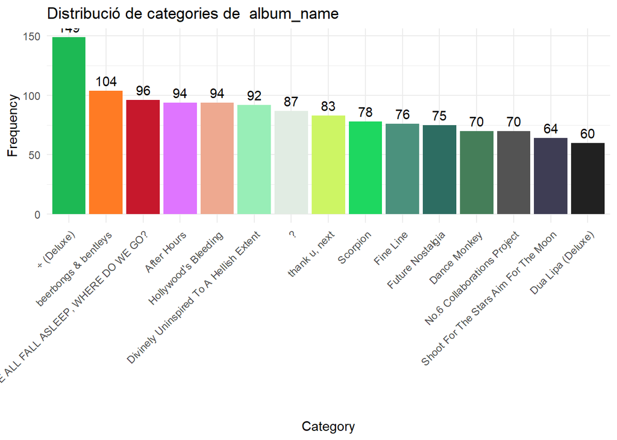

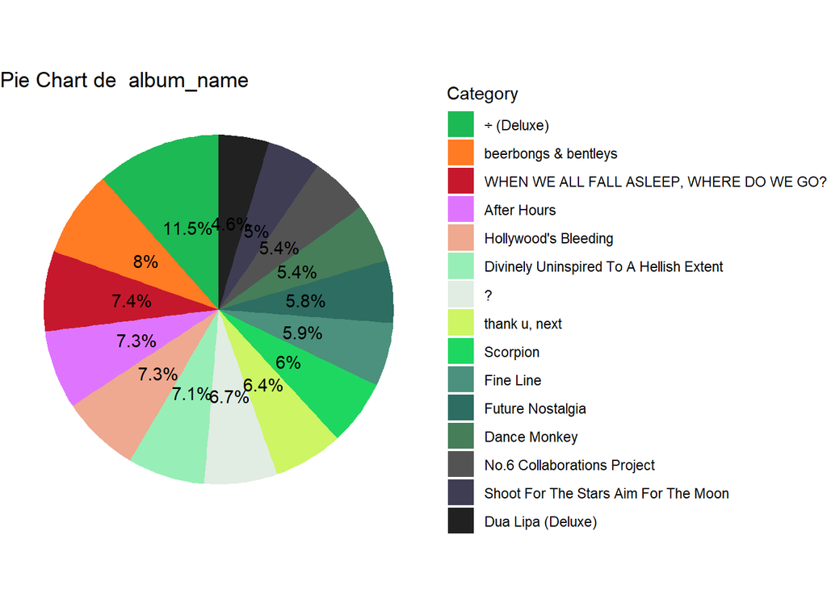

Nombre de modalitats: 769

Moda: ÷ (Deluxe)

Freqüència màxima: 149

## album_type

[1] album single single album single single Levels: album compilation single

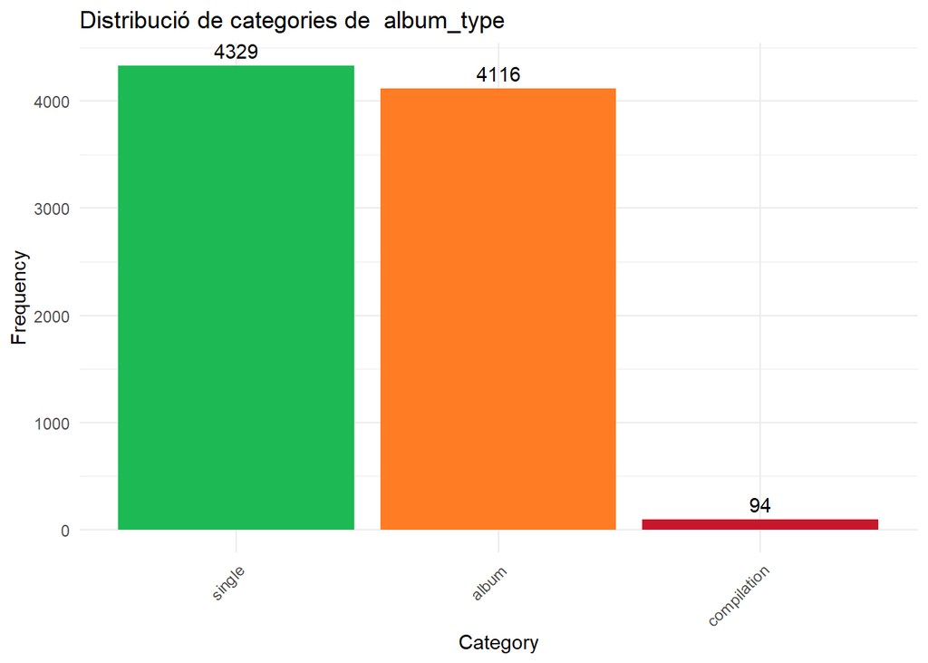

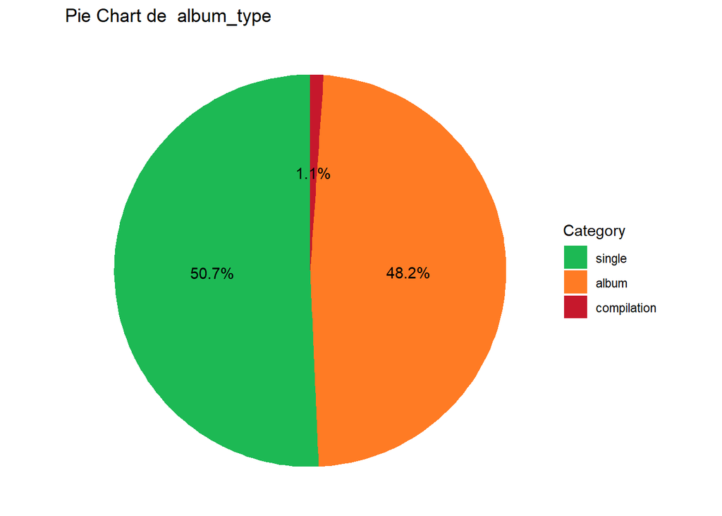

Nombre de modalitats: 3

Moda: single

Freqüència màxima: 4329

## album_label

[1] Universal Music Group Disruptor Records/Columbia [3] Atlantic Records UK Universal Music Group  
[5] Universal Music Group Universal Music Group  
247 Levels: (SME US Latin) Duars Entertainment, Corp. (2) …

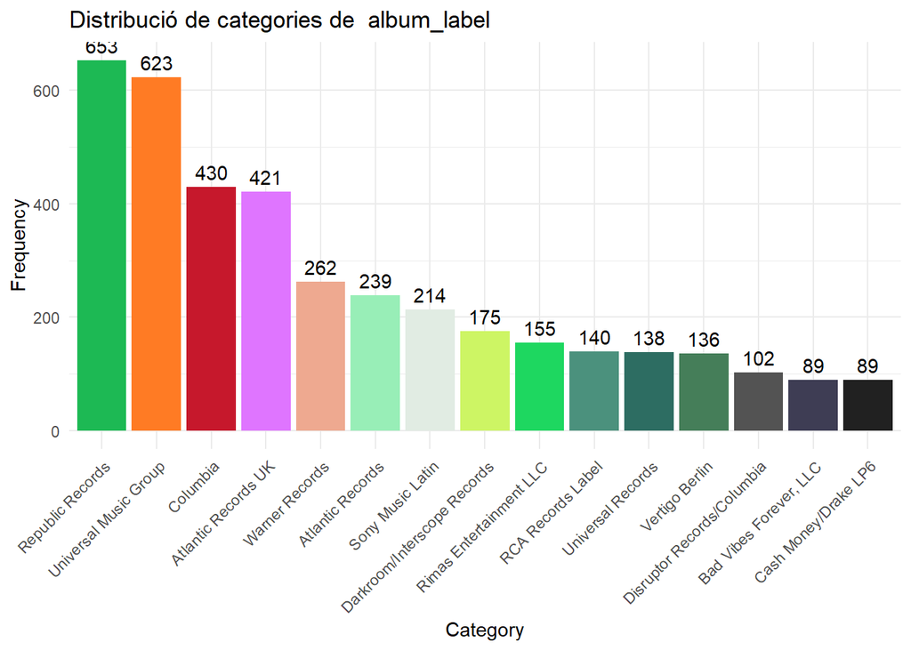

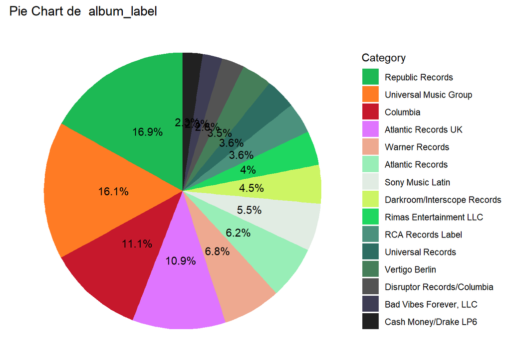

Nombre de modalitats: 247

Moda: Republic Records

Freqüència màxima: 653

## album_popularity

[1] 0 71 62 0 0 0

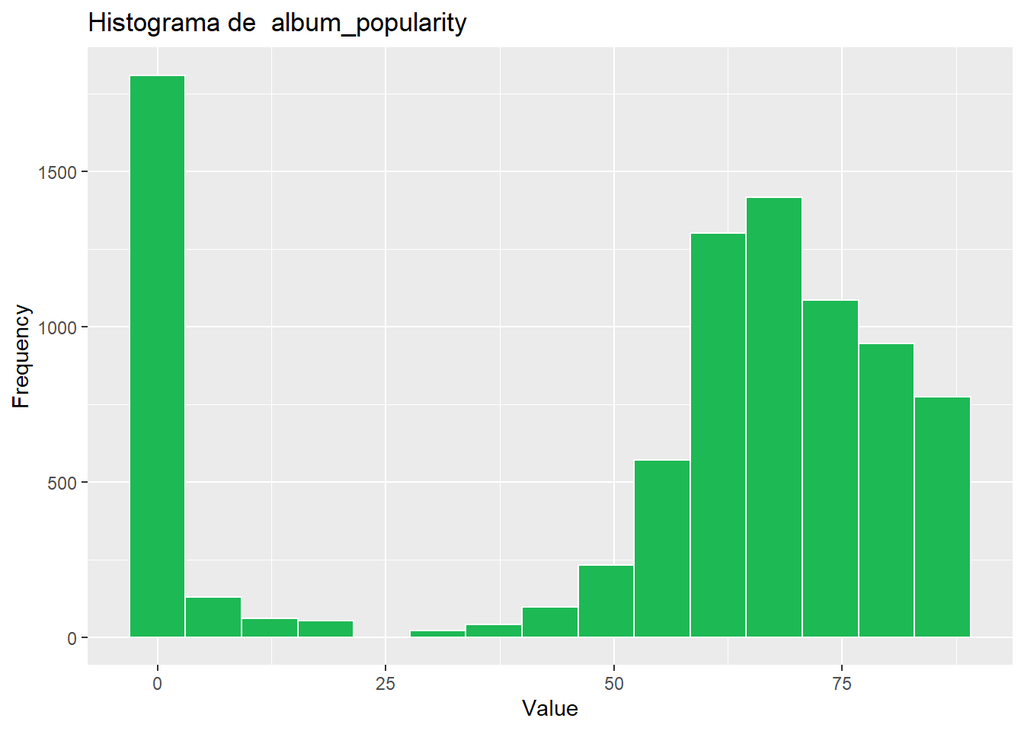

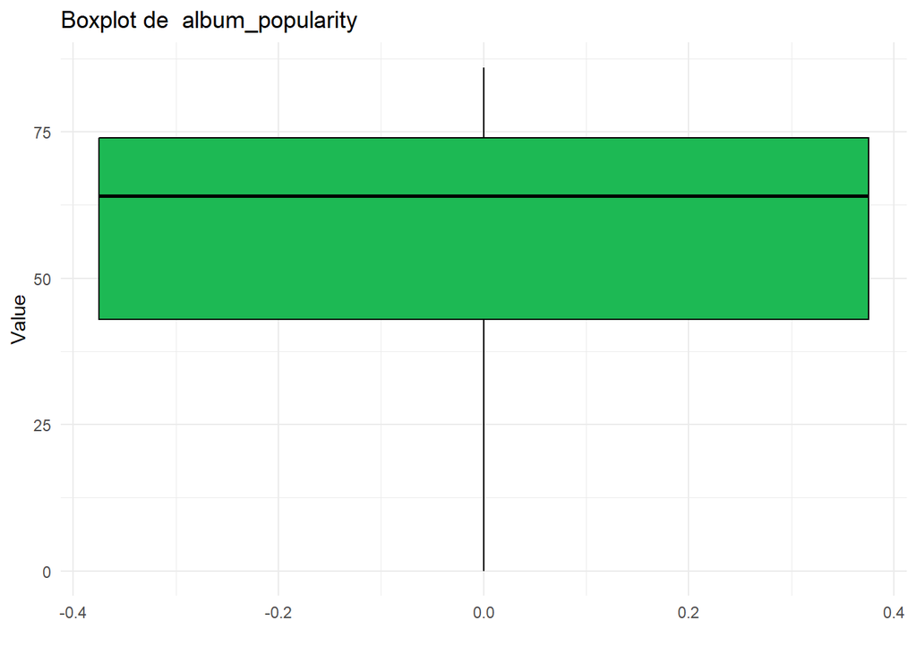

Mínim: 0 Màxim: 86

Primer quartil: 43 Mediana: 64 Tercer quartil: 74 Mitjana: 52.5674

## artist_num

[1] 2 2 3 2 2 2

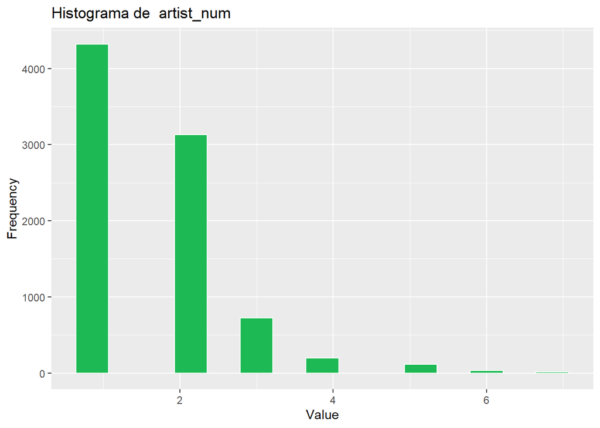

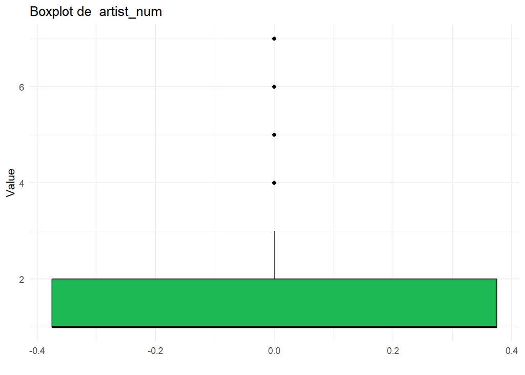

Mínim: 1 Màxim: 7

Primer quartil: 1 Mediana: 1 Tercer quartil: 2 Mitjana: 1.690011

## artist_name

[1] The Weeknd The Chainsmokers Clean Bandit DJ Snake  
[5] ZAYN Maroon 5  
300 Levels: 21 Savage 24kGoldn 5 Seconds of Summer … Zedd

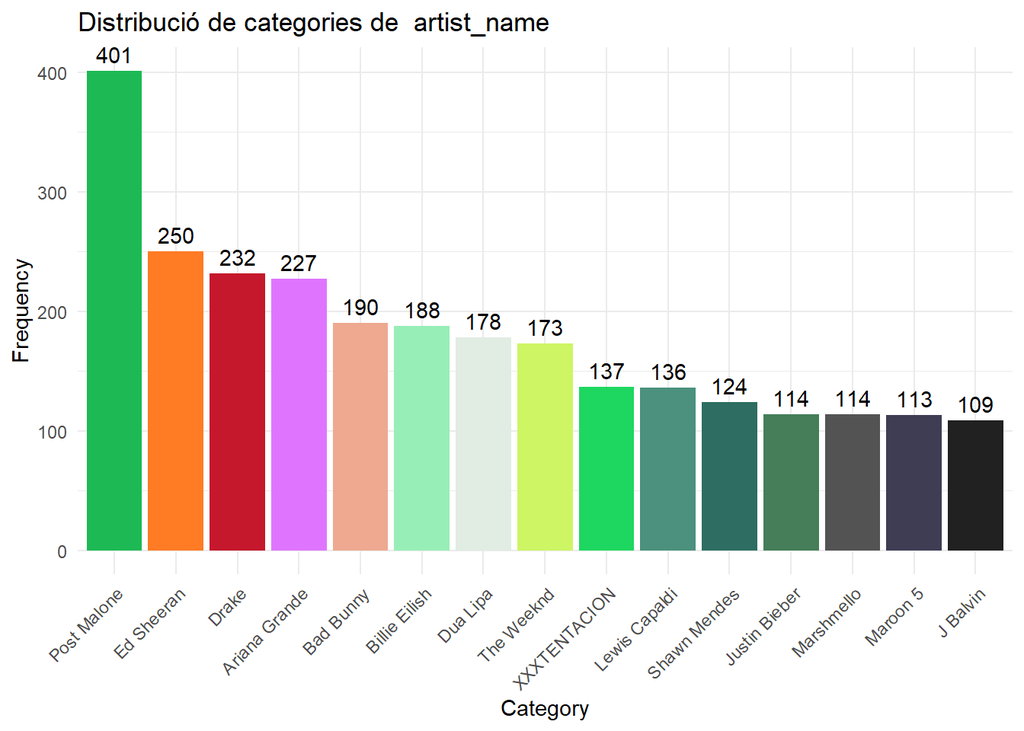

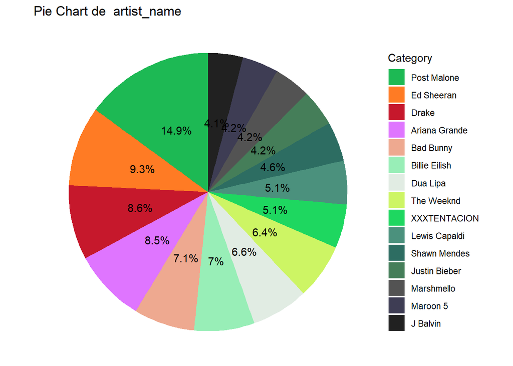

Nombre de modalitats: 300

Moda: Post Malone

Freqüència màxima: 401

## artist_followers

[1] 51215861 19562506 4943046 8137850 21433236 38266644

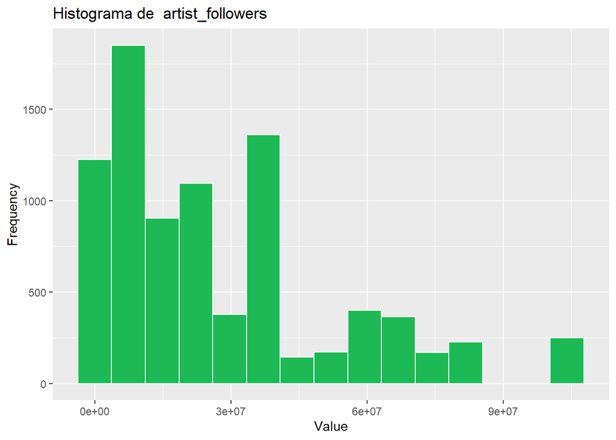

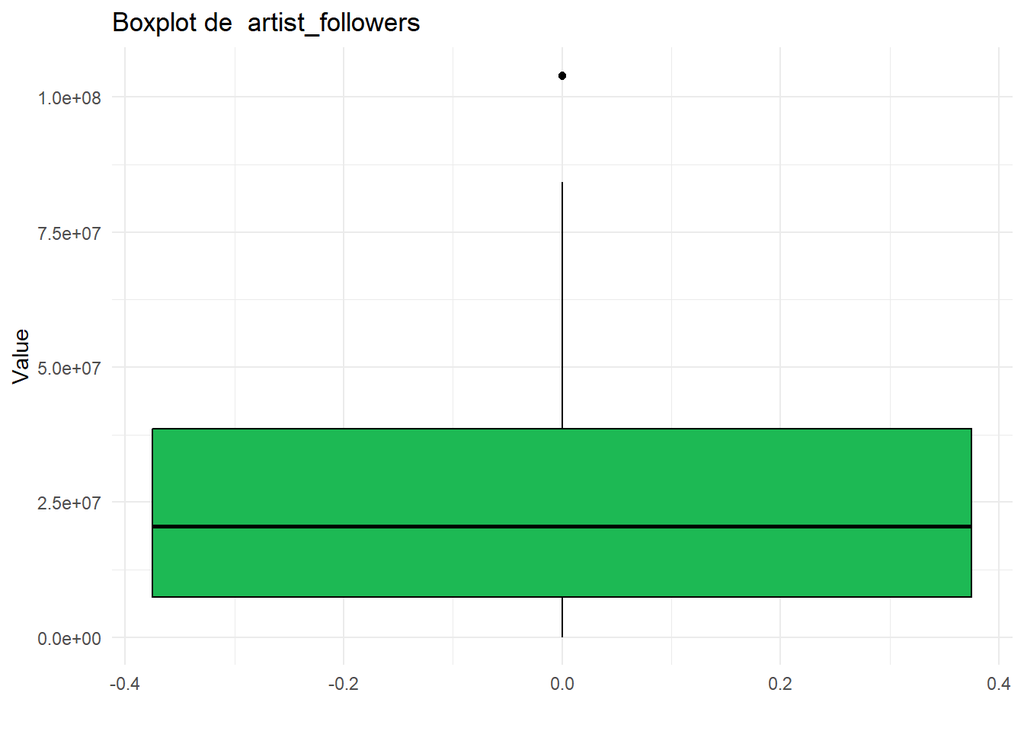

Mínim: 3805 Màxim: 104059839

Primer quartil: 7434109 Mediana: 20546114 Tercer quartil: 38523919 Mitjana: 27417641

## artist_popularity

[1] 94 81 76 78 77 86

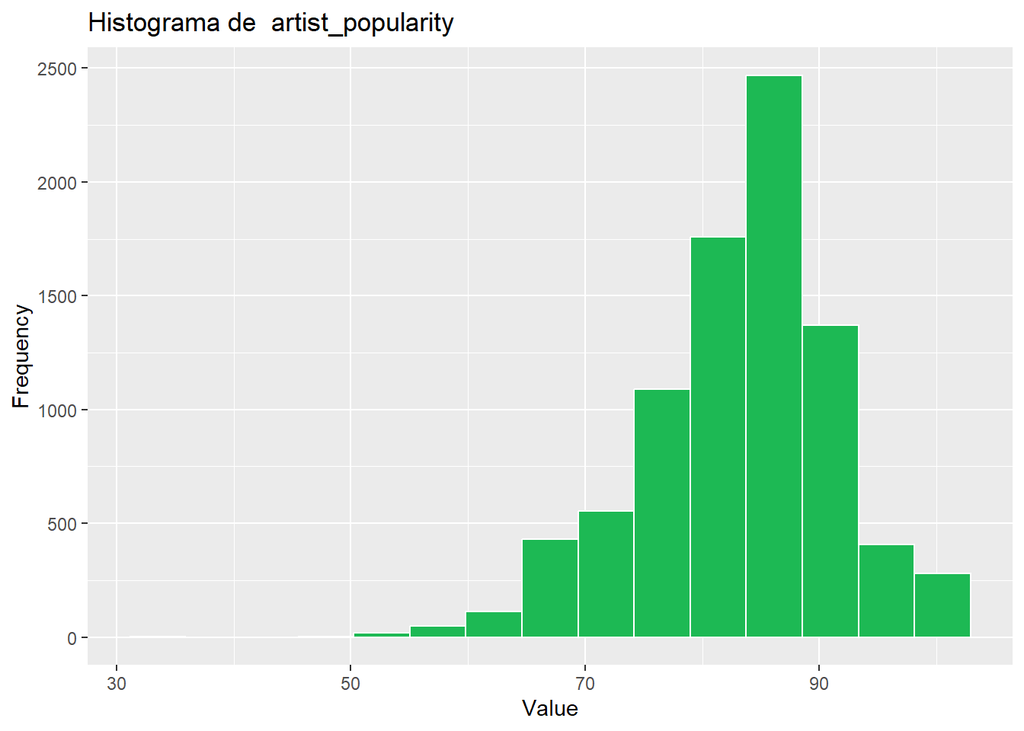

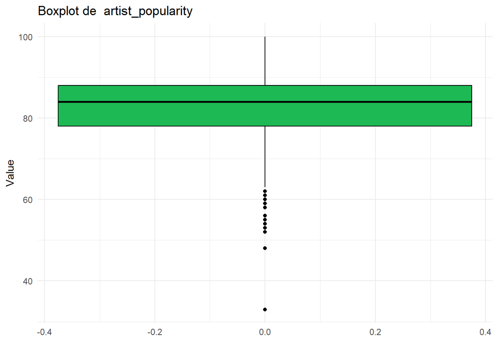

Mínim: 33 Màxim: 100

Primer quartil: 78 Mediana: 84 Tercer quartil: 88 Mitjana: 82.88793

## pop

[1] TRUE TRUE TRUE TRUE TRUE TRUE

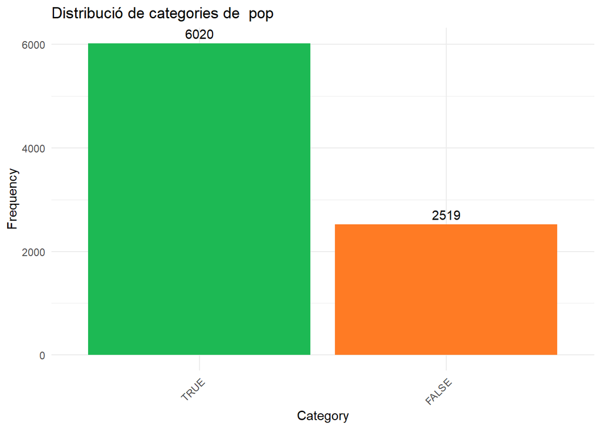

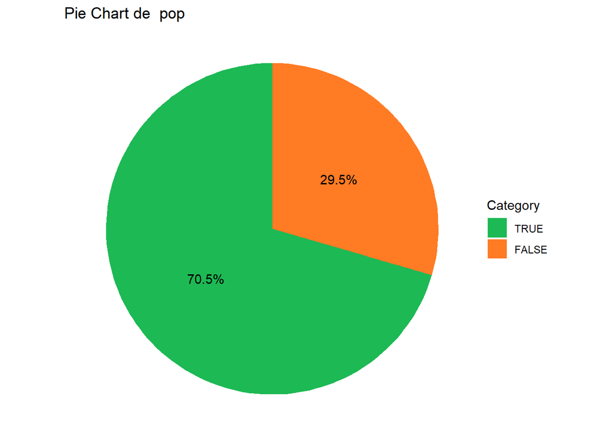

Nombre de modalitats: 2

Moda: TRUE

Freqüència màxima: 6020

## hip_hop

[1] FALSE FALSE FALSE TRUE FALSE FALSE

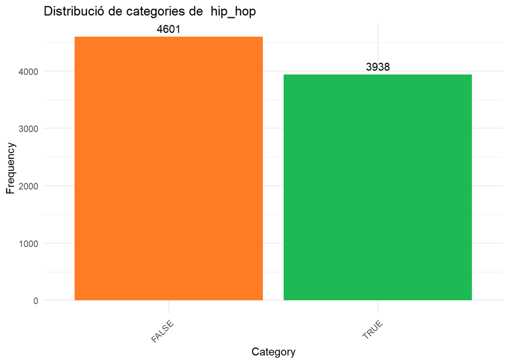

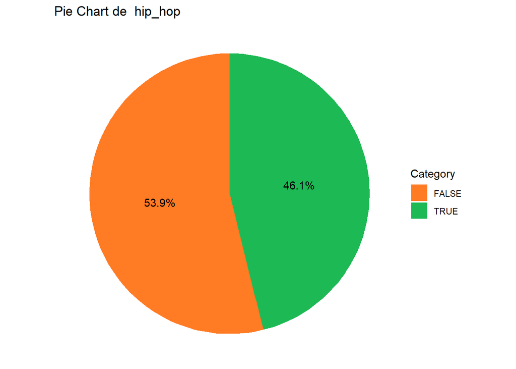

Nombre de modalitats: 2

Moda: FALSE

Freqüència màxima: 4601

## rock

[1] FALSE FALSE FALSE FALSE FALSE FALSE

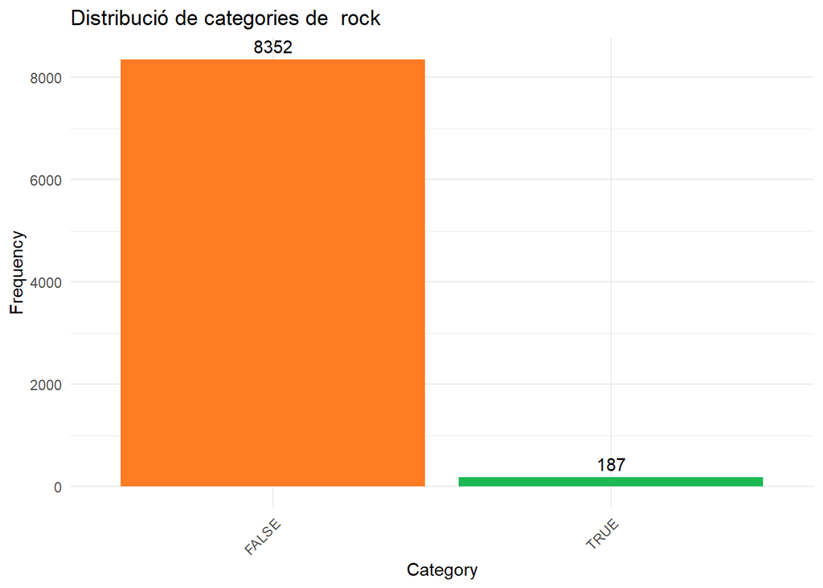

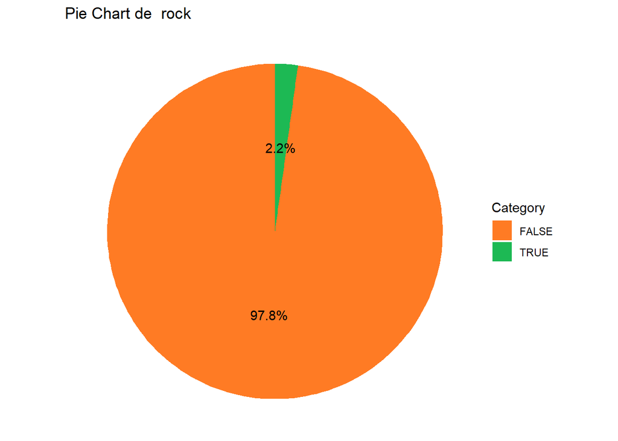

Nombre de modalitats: 2

Moda: FALSE

Freqüència màxima: 8352

## electro

[1] FALSE TRUE TRUE TRUE TRUE FALSE

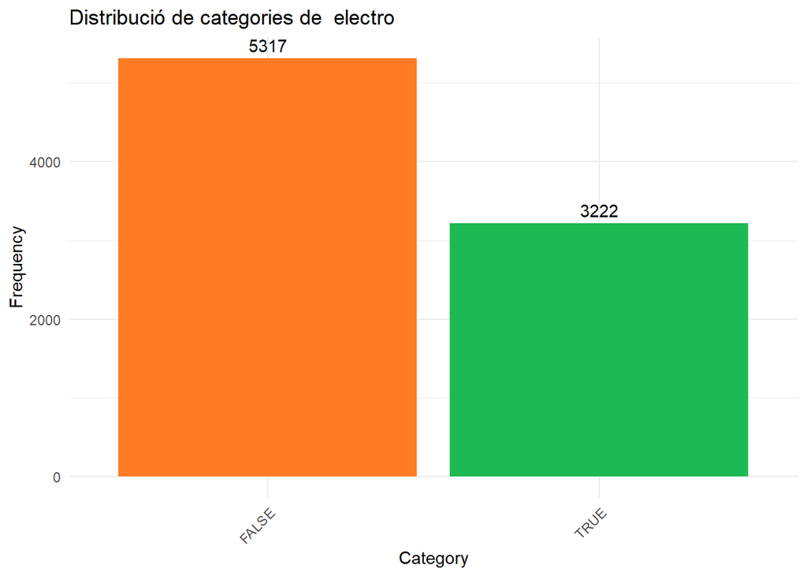

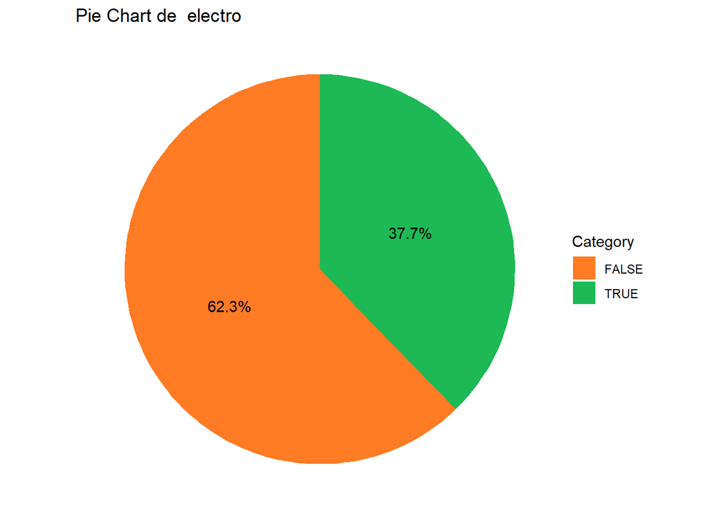

Nombre de modalitats: 2

Moda: FALSE

Freqüència màxima: 5317

## christmas

[1] FALSE FALSE FALSE FALSE FALSE FALSE

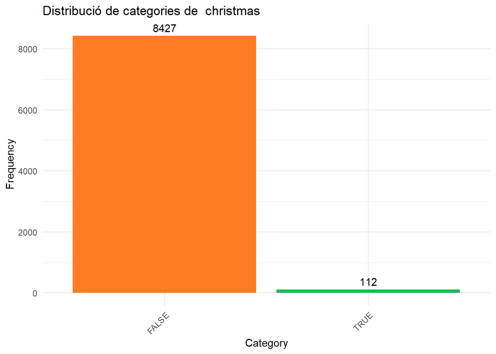

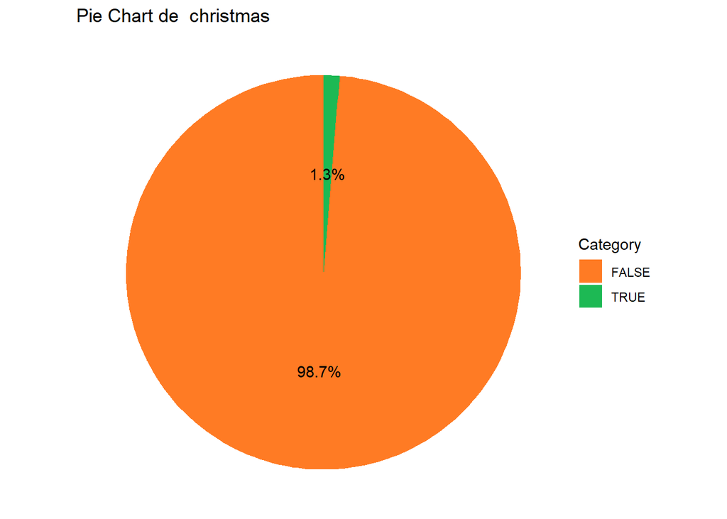

Nombre de modalitats: 2

Moda: FALSE

Freqüència màxima: 8427